# Visualizing Customer Segmentation with K-Means Clustering

A Marketing Analytics Approach to Grouping Similar Customers

Chengxu Liu

MGTA 495

2026-05-29

## Not All Customers Are the Same

**Marketing problem:**

A brand should not send the same message to every customer.

Some customers buy often. Some spend more. Some need a discount to come back.

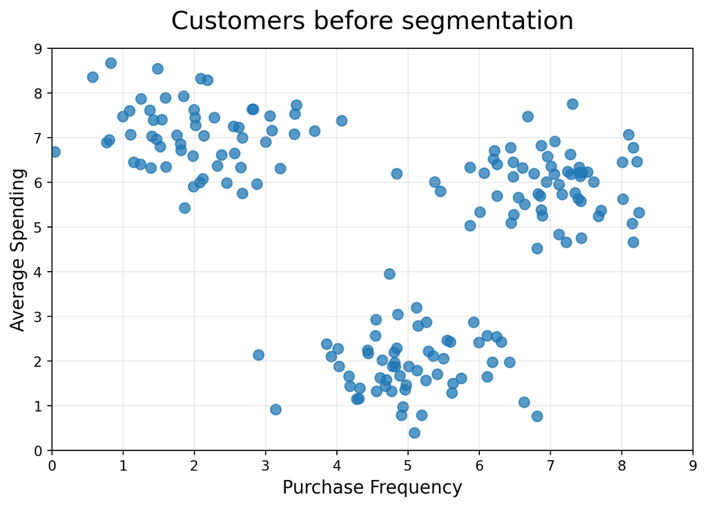

## What Clustering Does

**Clustering** groups customers who look similar.

In this example, we use two features:

- purchase frequency
- average spending

The goal is to find natural customer segments.

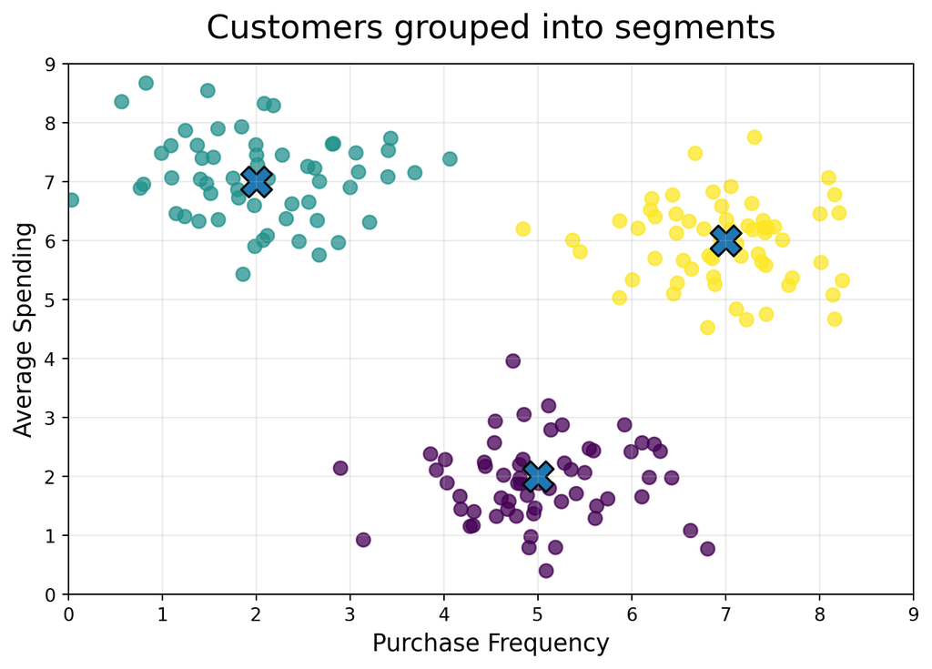

## How K-Means Moves

**Step 1**

Start with rough centers.

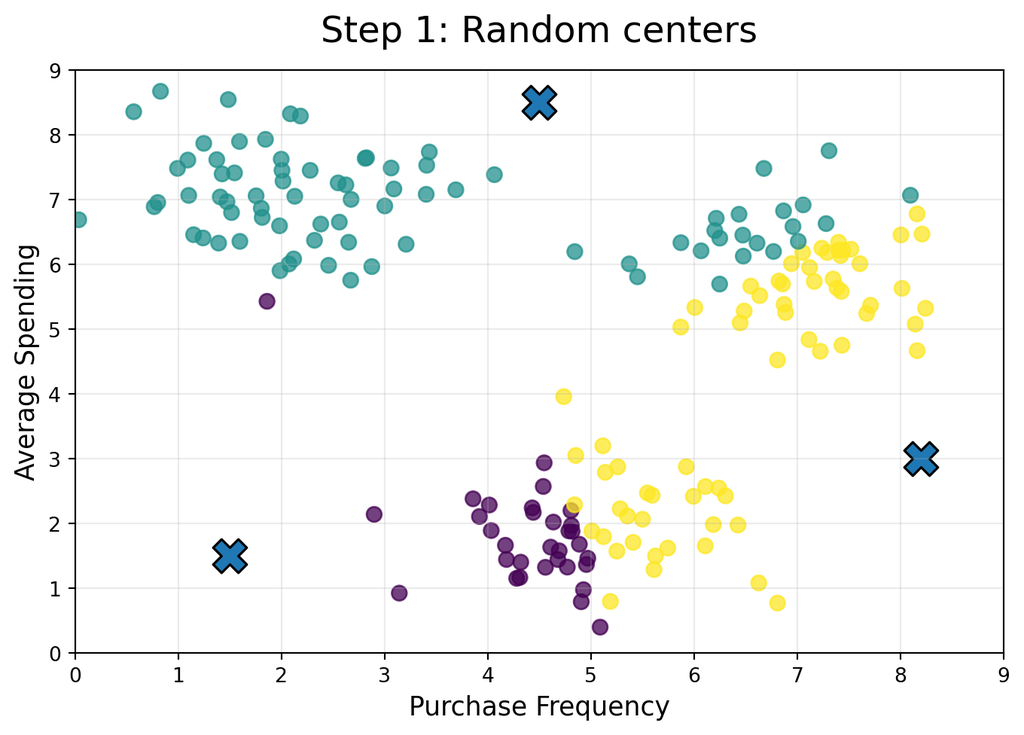

**Step 2**

Assign customers to the closest center.

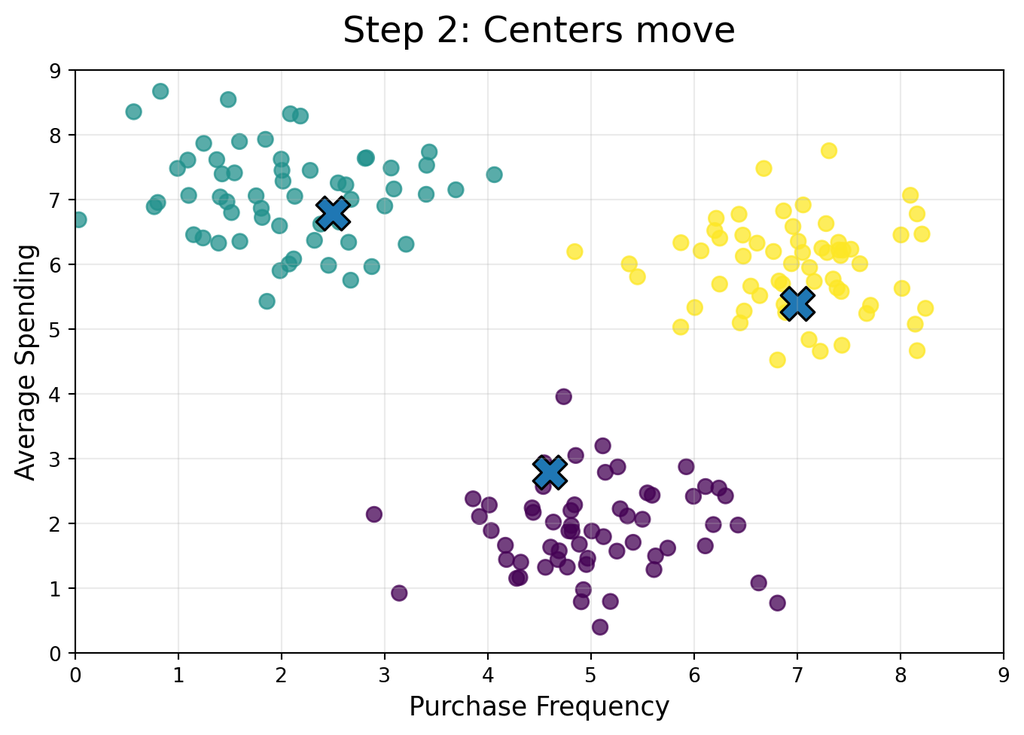

**Final**

Repeat until the groups are stable.

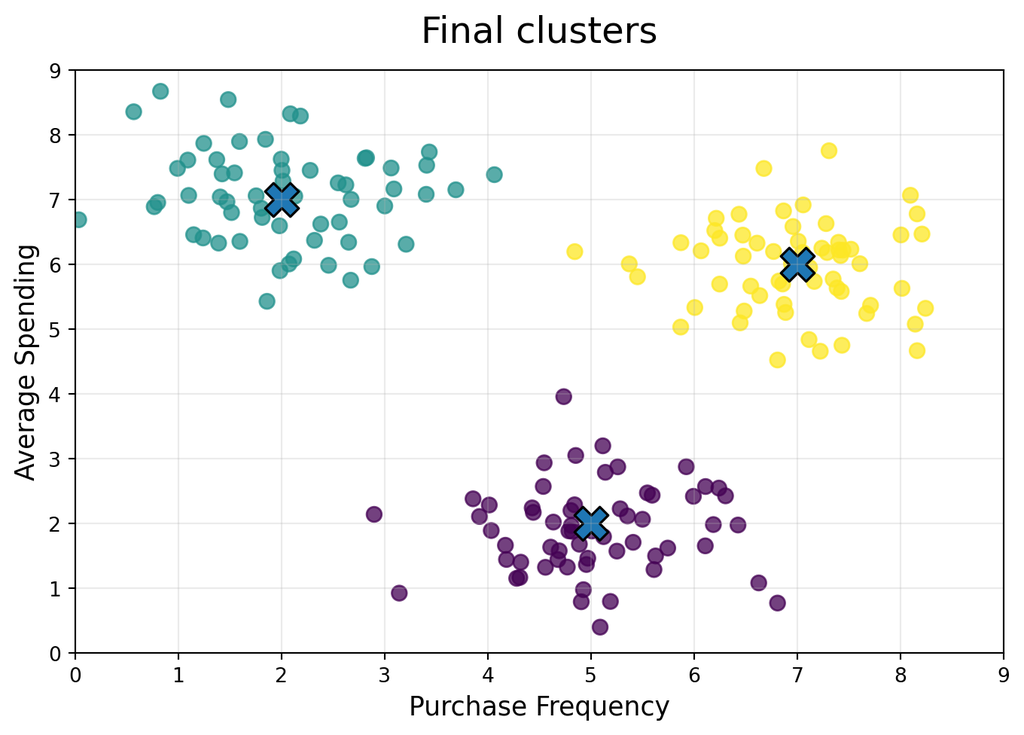

## Practical Problem 1: Too Many Variables

**Problem:** K-means depends on distance.

With too many variables, distance becomes harder to trust.

This is called the **curse of dimensionality**.

| Data size | What happens |
| --- | --- |
| 2 variables | Distance is easy to see |
| 10+ variables | Many points may look similarly far apart |
| Result | Clusters can become less meaningful |

**Practical fixes:**

- Select only useful variables
- Standardize before clustering
- Use PCA to reduce dimensions

## Practical Problem 2: Binary Variables

**Can we use 0/1 variables?**

Sometimes yes, but we need to be careful.

Examples:

- email subscriber
- used coupon
- app user

| Case | What to watch for |
| --- | --- |
| Balanced 0/1 | Usually more usable |
| Very rare 1s | May add little value |
| Many binary variables | K-means may not fit well |

**Better option:** For mixed data, consider **k-prototypes** or a mixed-data distance measure.

## Why This Helps Marketers

| Segment | What it means | Possible action |
| --- | --- | --- |
| High spending | Valuable customers | Loyalty reward |
| Frequent buyers | Already engaged | Cross-sell message |
| Low engagement | Need a push | Discount or reminder |

**Main idea:** Customer segmentation helps marketers send better messages to the right people.

**K-means is not magic. It is just a visual way to find similar customers.**